# DSApps 2023 @ TAU: Assignment 1

The Tidyverse - Part A

Giora Simchoni

2023-03-26

### Welcome

Welcome to Assignment 1 in R!

This is the first graded assignment where you actually have to *submit* a solution. So please pay attention:

- You can play with the assignment in Playground mode, but:
- Only your private Github repository assigned to you by the course admin will be cloned and graded (Submission mode, see instructions [here](https://github.com/DSApps-2023/Class_Slides/blob/master/Apps_of_DS_HW.pdf))
- Like any other University assignment, your work should remain private
- You need to `git clone` your private Github repository locally as explained [here](https://github.com/DSApps-2023/Class_Slides/blob/master/Apps_of_DS_HW.pdf)
- You need to uncomment the starter code inside the chunk, replace the `### YOUR CODE HERE ###`, run the chunk and see that you’re getting the expected result
- Pay attention to what you’re asked to do and the required output
- For example, using a *different* function than the one you were specifically asked to use, will decrease your score (unless you amaze me)
- Your notebook should run smoothly from start to end if someone presses in the RStudio toolbar Run –> Restart R and Run All Chunks
- When you’re done knit the entire notebook into a html file, this is the file that would be graded
- You can add other files but do not delete any files
- Commit your work and push to your private Github repository as explained [here](https://github.com/DSApps-2023/Class_Slides/blob/master/Apps_of_DS_HW.pdf)

This assignment is due: 27/3 23:59

### The `passwords` Dataset

The dataset we’ll explore in this assignment is the `passwords` dataset from [Information is Beautiful](https://informationisbeautiful.net/visualizations/top-500-passwords-visualized/) provided by the [Tidy Tuesday repo](https://github.com/rfordatascience/tidytuesday/tree/master/data/2020/2020-01-14).

This dataset contains ~500 top passwords ranked by popularity (variable `rank` where 1 is most popular). For each password we also get:

- its `strength` (0 is weakest)
- `category` - one of several categories, e.g. “fluffy”
- `offline_crack_sec` - Time to crack offline in seconds
- `value` - Time to crack by online guessing
- `time_unit` - Time unit to match with `value`

We will not be talking on what’s behind a password’s `strength` or “time to crack”, but you’re welcome to start reading about it [here](https://en.wikipedia.org/wiki/Password_strength).

### Packages

These are the packages you will need. If you don’t have them, you need to uncomment the `install.packages()` line and install them first (you can also just copy this command to the R console and do it there if you don’t want all the output printed in this notebook).

When you load the packages you may see different kinds of messages or warnings, skim them:

```r
#install.packages("tidyverse")
library(tidyverse)
```

### Read In Data

##### (10 points)

Read in the `passwords.csv` located at URL “https://raw.githubusercontent.com/rfordatascience/tidytuesday/master/data/2020/2020-01-14/passwords.csv”. Use the [`read_csv()`](https://readr.tidyverse.org/reference/read_delim.html) function from the `readr` package, already loaded if you loaded the `tidyverse` package.

```r
passwords <- read_csv("https://raw.githubusercontent.com/rfordatascience/tidytuesday/master/data/2020/2020-01-14/passwords.csv")
```

Take a `glimpse()` at the data:

```r
glimpse(passwords)
```

```
## Rows: 507
## Columns: 9
## $ rank              <dbl> 1, 2, 3, 4, 5, 6, 7, 8, 9, 10, 11, 12, 13, 14, 15, 1…
## $ password          <chr> "password", "123456", "12345678", "1234", "qwerty", …
## $ category          <chr> "password-related", "simple-alphanumeric", "simple-a…
## $ value             <dbl> 6.91, 18.52, 1.29, 11.11, 3.72, 1.85, 3.72, 6.91, 6.…
## $ time_unit         <chr> "years", "minutes", "days", "seconds", "days", "minu…
## $ offline_crack_sec <dbl> 2.170e+00, 1.110e-05, 1.110e-03, 1.110e-07, 3.210e-0…
## $ rank_alt          <dbl> 1, 2, 3, 4, 5, 6, 7, 8, 9, 10, 11, 12, 13, 14, 15, 1…
## $ strength          <dbl> 8, 4, 4, 4, 8, 4, 8, 4, 7, 8, 8, 1, 32, 9, 9, 8, 8, …
## $ font_size         <dbl> 11, 8, 8, 8, 11, 8, 11, 8, 11, 11, 11, 4, 23, 12, 12…
```

Print the number of rows and columns (no need to make it “pretty”):

```r
dim(passwords)
```

```
## [1] 507   9
```

### Basic `dplyr` Verbs

##### (20 points)

Filter only passwords from the “fluffy” category (use only Tidyverse functions!):

```r
passwords %>% filter(category == "fluffy") %>% select(password)
```

```
## # A tibble: 44 × 1
##    password
##    <chr>
##  1 love
##  2 sunshine
##  3 silver
##  4 orange
##  5 ginger
##  6 summer
##  7 princess
##  8 diamond
##  9 yellow
## 10 iloveyou
## # ℹ 34 more rows
```

Filter only passwords in the “sport” and “cool-macho” and select only the `rank`, `password`, `category` and `strength` columns:

```r
passwords %>% filter(category %in% c("sport", "cool-macho")) %>% select(rank, password, category, strength)
```

```
## # A tibble: 116 × 4
##     rank password category   strength
##    <dbl> <chr>    <chr>         <dbl>
##  1     8 baseball sport             4
##  2     9 football sport             7
##  3    14 mustang  cool-macho        9
##  4    16 shadow   cool-macho        8
##  5    17 master   cool-macho        8
##  6    23 harley   cool-macho        8
##  7    25 hunter   cool-macho        8
##  8    27 ranger   cool-macho        7
##  9    28 buster   cool-macho        8
## 10    32 soccer   sport             6
## # ℹ 106 more rows
```

Same as above, but sort by `strength`, from weakest to strongest (and do try to make this in a single pipe):

```r
passwords %>% filter(category %in% c("sport", "cool-macho")) %>% select(rank, password, category, strength) %>% arrange(strength)
```

```
## # A tibble: 116 × 4
##     rank password category   strength
##    <dbl> <chr>    <chr>         <dbl>
##  1   324 voodoo   cool-macho        0
##  2   298 success  cool-macho        2
##  3   337 beer     cool-macho        3
##  4   387 cool     cool-macho        3
##  5   413 free     cool-macho        3
##  6     8 baseball sport             4
##  7    56 dallas   sport             5
##  8   170 yamaha   sport             5
##  9   328 apollo   cool-macho        5
## 10   363 runner   sport             5
## # ℹ 106 more rows
```

Create a new column `is_123` which will hold TRUE if the password contains the string “123” and FALSE otherwise. Use the [`mutate()`](https://dplyr.tidyverse.org/reference/mutate.html) function and have a look at the [`str_detect()`](https://stringr.tidyverse.org/reference/str_detect.html) function from the `stringr` package, already loaded if you loaded the `tidyverse` package.

```r
passwords <- passwords %>% mutate(is_123 = str_detect(password, "123"))
```

Use the column you created to filter only passwords containing “123”, use the [`pull()`](https://dplyr.tidyverse.org/reference/pull.html) function to extract those passwords as a vector called `passwords_with_123` and print it:

```r
passwords_with_123 <- passwords %>% filter(is_123 == T) %>% pull(password)
print(passwords_with_123)
```

```
##  [1] "123456"    "12345678"  "1234"      "12345"     "abc123"    "1234567"
##  [7] "123456789" "123123"    "red123"    "123321"    "123abc"    "test123"
```

Use the [`summarise()`](https://dplyr.tidyverse.org/reference/summarise.html) function to get the mean`strength` of passwords in the “food” category:

```r
passwords %>%
   filter(category == "food") %>%
   summarise(mean(strength))
```

```
## # A tibble: 1 × 1
##   `mean(strength)`
##              <dbl>
## 1             4.36
```

### `group_by`, `summarize` and `count`

##### (20 points)

Group the data by `category`, extract the mean strength in each category and sort by mean strength descending. Be sure to remove `NA` values if necessary:

```r
passwords %>% group_by(category) %>%
   summarise(mean_strength = mean(strength, na.rm = T)) %>% arrange(-mean_strength)
```

```
## # A tibble: 11 × 2
##    category            mean_strength
##    <chr>                       <dbl>
##  1 nerdy-pop                   14
##  2 sport                        8
##  3 password-related             7.87
##  4 animal                       7.55
##  5 cool-macho                   7.22
##  6 name                         7.19
##  7 fluffy                       6.77
##  8 rebellious-rude              6.73
##  9 simple-alphanumeric          5.85
## 10 food                         4.36
## 11 <NA>                       NaN
```

Count how many passwords appear in each category. Do not use the `group_by()` function.

```r
passwords %>% count(category)
```

```
## # A tibble: 11 × 2
##    category                n
##    <chr>               <int>
##  1 animal                 29
##  2 cool-macho             79
##  3 fluffy                 44
##  4 food                   11
##  5 name                  183
##  6 nerdy-pop              30
##  7 password-related       15
##  8 rebellious-rude        11
##  9 simple-alphanumeric    61
## 10 sport                  37
## 11 <NA>                    7
```

Combine the above two outputs in a single pipe: a table with a category’s name `category`, `n` the number of passwords in it and `mean_strength`, their mean strength without `NA` values. Now you *may* use `group_by()` and also have a look at [`n()`](https://dplyr.tidyverse.org/reference/n.html):

```r
passwords %>%
  group_by(category) %>%
  summarise(mean_strength = mean(strength, na.rm = T), n = n())
```

```
## # A tibble: 11 × 3
##    category            mean_strength     n
##    <chr>                       <dbl> <int>
##  1 animal                       7.55    29
##  2 cool-macho                   7.22    79
##  3 fluffy                       6.77    44
##  4 food                         4.36    11
##  5 name                         7.19   183
##  6 nerdy-pop                   14       30
##  7 password-related             7.87    15
##  8 rebellious-rude              6.73    11
##  9 simple-alphanumeric          5.85    61
## 10 sport                        8       37
## 11 <NA>                       NaN        7
```

### `distinct`, `case_when` and `rename`

##### (10 points)

Print the `distinct()` (or `unique()`) categories of passwords containing “123”:

```r
passwords %>%
  filter(is_123 == T) %>%
  distinct(category)
```

```
## # A tibble: 1 × 1
##   category
##   <chr>
## 1 simple-alphanumeric
```

Create a new column `time_unit_seconds` which will hold for each `time_unit` the number of **seconds** it represents (or `NA` if it is `NA`).

For your convenience:

- a minute is 60 seconds
- an hour is 3600 seconds
- a day is 86400 seconds
- a week is 604800 seconds
- a month is 2629746 seconds (with 30.436875 days…)
- a year is 31536000 seconds (with 365 days)

```r
passwords <- passwords %>%
  mutate(time_unit_seconds = case_when(
     time_unit == 'seconds' ~ 1,
     time_unit == 'minutes' ~ 60,
     time_unit == 'hours' ~ 3600,
     time_unit == 'days' ~ 86400,
     time_unit == 'weeks' ~ 604800,
     time_unit == 'months' ~ 2629746,
     time_unit == 'years' ~ 31536000,
     TRUE ~ NA_real_
   ))
```

Do the same as above (yes, again), but now use the `case_match()` function, and in addition add a new column `value_seconds` which contains the “Time to crack by online guessing **in seconds**”, using the `time_unit_seconds` column you have just created. Create the two columns with a single call to `mutate()`:

```r
passwords <- passwords %>%
   mutate(time_unit_seconds = case_match(
     time_unit,
     'seconds' ~ 1,
     'minutes' ~ 60,
     'hours' ~ 3600,
     'days' ~ 86400,
     'weeks' ~ 604800,
     'months' ~ 2629746,
     'years' ~ 31536000,
     NA ~ NA,
     .default = value),
     value_seconds = time_unit_seconds*value)
```

On second thought I don’t like the `value_seconds` column name, change it to something more meaningful, like `time_to_crack_sec`:

```r
passwords <- passwords %>%
  rename(time_to_crack_sec = value_seconds)
```

### `select_if` and `across`

##### (10 points)

See that the transformation you just made worked by selecting only numeric columns:

```r
passwords %>%
  select_if(is.numeric)
```

```
## # A tibble: 507 × 8
##     rank value offline_crack_sec rank_alt strength font_size time_unit_seconds
##    <dbl> <dbl>             <dbl>    <dbl>    <dbl>     <dbl>             <dbl>
##  1     1  6.91       2.17               1        8        11          31536000
##  2     2 18.5        0.0000111          2        4         8                60
##  3     3  1.29       0.00111            3        4         8             86400
##  4     4 11.1        0.000000111        4        4         8                 1
##  5     5  3.72       0.00321            5        8        11             86400
##  6     6  1.85       0.00000111         6        4         8                60
##  7     7  3.72       0.00321            7        8        11             86400
##  8     8  6.91       2.17               8        4         8          31536000
##  9     9  6.91       2.17               9        7        11          31536000
## 10    10  3.19       0.0835            10        8        11           2629746
## # ℹ 497 more rows
## # ℹ 1 more variable: time_to_crack_sec <dbl>
```

Use the `recode_yes_no()` function below to have **all logical columns** contain either “Yes” or “No” instead of TRUE or FALSE (use `across()`!):

```r
recode_yes_no <- function(bool) ifelse(bool, "Yes", "No")

passwords <- passwords %>%
  mutate(across(where(is.logical),recode_yes_no))
```

For each of the columns `time_to_crack_sec` and `offline_crack_sec` add another column with suffix “_log” (i.e. `time_to_crack_sec_log` and `offline_crack_log`), holding the log of that quantity (use `across()`!):

```r
passwords <- passwords %>%
  mutate(across( c(`time_to_crack_sec`, `offline_crack_sec`), list(log = log) ))
```

Just so you won’t get too bored, run this chunk to see the scatterplot of `time_to_crack_sec_log` by `strength`:

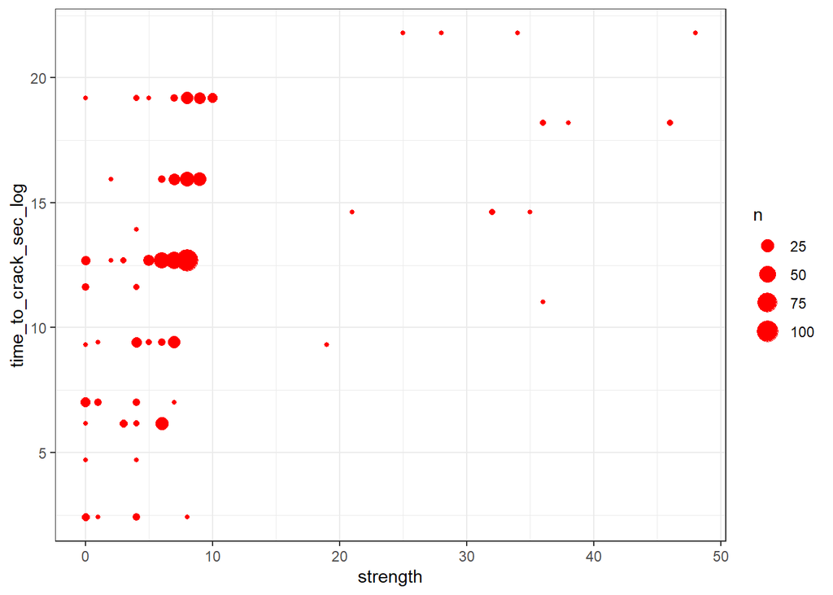

```r
passwords %>%
  count(strength, time_to_crack_sec_log) %>%
  ggplot(aes(strength, time_to_crack_sec_log)) +
  geom_point(aes(size = n), color = "red") +
  theme_bw()
```

Same, but with popularity `rank`:

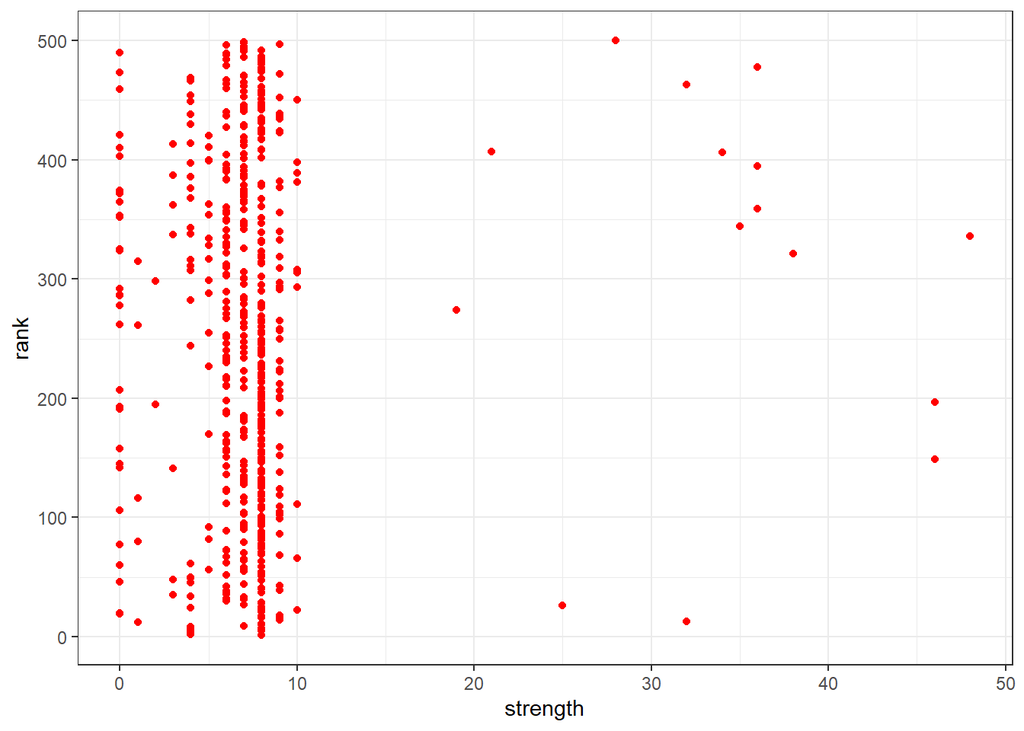

```r
ggplot(passwords, aes(strength, rank)) +
  geom_point(color = "red") +
  theme_bw()
```

(What do you think is that very popular password (low `rank`) and very high `strength`? Do you agree with `strength` in this case?)

And here is the distribution of `time_to_crack_sec_log` by `category`:

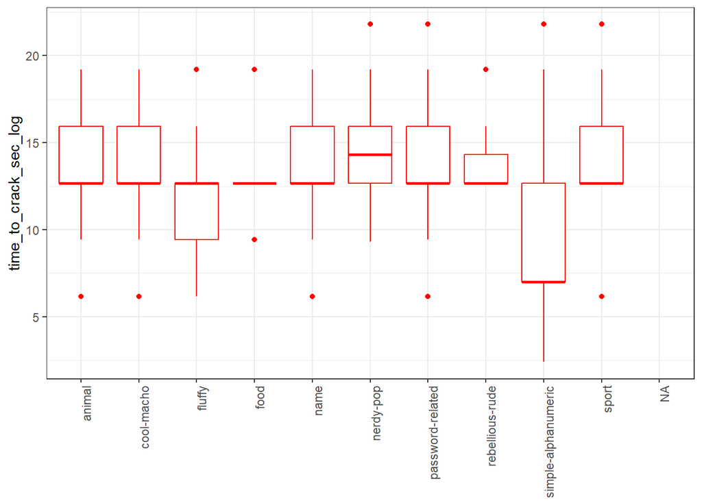

```r
ggplot(passwords, aes(category, time_to_crack_sec_log)) +
  geom_boxplot(color = "red") +
  labs(x = NULL) +
  theme_bw() +
  theme(axis.text.x = element_text(angle = 90, hjust = 1))
```

### Dealing with NAs

##### (10 points)

Put a filtered version of the `passwords` dataset without `NA` values in `passwords_no_na`. Use the `drop_na()` function within a pipe:

```r
passwords_no_na <- passwords %>% drop_na()
```

If you read carefully the columns definition in the [Tidy Tuesday repo](https://github.com/rfordatascience/tidytuesday/tree/master/data/2020/2020-01-14), you might have noticed that `strength` should cap at 10, whereas it clearly does not:

```r
passwords %>%
  arrange(-strength) %>%
  select(rank, password, strength) %>%
  slice(1:10)
```

```
## # A tibble: 10 × 3
##     rank password strength
##    <dbl> <chr>       <dbl>
##  1   336 rush2112       48
##  2   149 ncc1701        46
##  3   197 thx1138        46
##  4   321 bond007        38
##  5   359 ou812          36
##  6   395 heka6w2        36
##  7   478 test123        36
##  8   344 red123         35
##  9   406 jordan23       34
## 10    13 abc123         32
```

Let’s assume we’re bothered by that and would like to replace all values of `strength` above 10 with `NA`. Use the `replace` function in a pipe, taking inspiration from [this](https://stackoverflow.com/a/27909037/4095235) StackOverflow answer:

```r
passwords <- passwords %>%
  mutate(strength = replace(strength, strength > 10, NA))
```

See that it worked by filtering only passwords with `NA` for `strength`, do this in a pipe (no starter code, I want you to be able to Google stuff you don’t know):

```r
passwords %>% filter(is.na(strength))
```

```
## # A tibble: 22 × 14
##     rank password category   value time_unit offline_crack_sec rank_alt strength
##    <dbl> <chr>    <chr>      <dbl> <chr>                 <dbl>    <dbl>    <dbl>
##  1    13 abc123   simple-al…  3.7  weeks              0.0224         13       NA
##  2    26 trustno1 simple-al… 92.3  years             29.0            26       NA
##  3   149 ncc1701  nerdy-pop   2.56 years              0.806         149       NA
##  4   197 thx1138  nerdy-pop   2.56 years              0.806         198       NA
##  5   274 8675309  nerdy-pop   3.09 hours              0.000111      275       NA
##  6   321 bond007  nerdy-pop   2.56 years              0.806         322       NA
##  7   336 rush2112 nerdy-pop  92.3  years             29.0           337       NA
##  8   344 red123   simple-al…  3.7  weeks              0.0224        345       NA
##  9   359 ou812    nerdy-pop  17.3  hours              0.000622      360       NA
## 10   395 heka6w2  simple-al…  2.56 years              0.806         396       NA
## # ℹ 12 more rows
## # ℹ 6 more variables: font_size <dbl>, is_123 <chr>, time_unit_seconds <dbl>,
## #   time_to_crack_sec <dbl>, time_to_crack_sec_log <dbl>,
## #   offline_crack_sec_log <dbl>
```

Now let’s assume we regret this, but now deleted `strength` values are lost, and so we put the maximum value we know, 10, to all passwords for which we don’t know what `strength` is. Use the [`replace_na()`](https://tidyr.tidyverse.org/reference/replace_na.html) function from the `tidyr` package:

```r
passwords <- passwords %>%
 replace_na(list(strength = 10))
```

### Writing functions

##### (10 points)

Remember when we checked the mean strength for “food” passwords?

Write a function which returns (in a `tibble`) for a given `categ` its mean `rank`, mean `strength` and mean `time_to_crack_sec_log`, ignoring `NA` values:

```r
category_mean_strength <- function(categ) {
   passwords %>%
      drop_na() %>%
      filter(category == categ) %>%
      summarise(mean(rank), mean(strength), mean(time_to_crack_sec_log)) %>%
      mutate(categ = categ) %>%
      as_tibble()
}

## Usage
category_mean_strength("fluffy")
```

```
## # A tibble: 1 × 4
##   `mean(rank)` `mean(strength)` `mean(time_to_crack_sec_log)` categ
##          <dbl>            <dbl>                         <dbl> <chr>
## 1         240.             6.77                          12.0 fluffy
```

Write a “tidy” function which accepts one of the numerical variables (unquoted) name and returns its *median* for every category, ignoring `NA` values. No need to check input:

(Remember the `count_var_for_gender` from class)

```r
median_per_category <- function(numeric_var) {
  passwords %>%
  drop_na() %>%
  group_by(category) %>%
  summarise(median({{numeric_var}}))
}

# Usage
median_per_category(strength)
```

```
## # A tibble: 10 × 2
##    category            `median(strength)`
##    <chr>                            <dbl>
##  1 animal                               7
##  2 cool-macho                           8
##  3 fluffy                               7
##  4 food                                 5
##  5 name                                 8
##  6 nerdy-pop                            8
##  7 password-related                     7
##  8 rebellious-rude                      7
##  9 simple-alphanumeric                  4
## 10 sport                                8
```

### Paper questions

##### (10 points)

Read Section 4.3 of Hadley Wickham’s [Tidy Data](https://www.jstatsoft.org/article/view/v059i10) 2014 paper (of course you’re invited to read the whole thing!).

Let’s see exactly what Wickham is talking about. Run this simple `lm` linear model:

```r
x1 <- rnorm(100)
x2 <- rnorm(100)
y <- x1 + x2 + rnorm(100, sd = 0.1)

lm_obj <- lm(y ~ x1 + x2)
```

Now, without loading any additional packages, extract by code the p-value for `x2` from the linear model:

```r
summary(lm_obj)$coefficients['x2','Pr(>|t|)']
```

```
## [1] 2.646297e-99
```

Dreadful! Now Wickham says:

> This knocks you out of the flow of analysis and makes it harder to combine the results from multiple models. I’m not currently aware of any packages that resolve this problem.

But things have changed! Google “tidy lm output” and show how to extract that p-value **tidily** (now you can use additional libraries):

```r
#install.packages('broom')
library(broom)
tidy(lm_obj) %>% filter(term == 'x2') %>% select(p.value)
```

```
## # A tibble: 1 × 1
##    p.value
##      <dbl>
## 1 2.65e-99
```

### Wrap up

And that’s it, you have shown you can wrangle data in the Tidyverse, in a concise, consistent and extensible manner. You also know which passwords not to use. Good luck with the rest of the course!